# Activity: Bird Species

Vydeepthi Dhulipalla

June 7,2023

# Set Up

```r
# Load `tidyverse` and `dcData` packages

library(tidyverse)
library(dcData)

# Load the `OrdwayBirds` data set into your RStudio environment from the `dcData` package

data(OrdwayBirds, package = "dcData")

# Show a few commands used to inspect the data set a few different ways

glimpse(OrdwayBirds)
```

```
Rows: 15,829
Columns: 26
$ bogus             <chr> ".", ".", ".", ".", ".", ".", ".", ".", ".", ".", ".", ".", ".", ".", ".", ".",…
$ Timestamp         <chr> "4/14/2010 13:20:56", "", "5/13/2010 16:00:30", "5/13/2010 16:02:15", "5/13/201…
$ Year              <chr> "1972", "", "1972", "1972", "1972", "1972", "1972", "1972", "1972", "1972", "19…
$ Day               <chr> "16", "", "16", "16", "16", "16", "16", "16", "16", "16", "17", "18", "18", "18…
$ Month             <chr> "7", "", "7", "7", "7", "7", "7", "7", "7", "7", "7", "7", "7", "7", "7", "7", …
$ CaptureTime       <chr> "7:00:00", "", "7:00:00", "7:00:00", "7:00:00", "7:00:00", "13:00:00", "13:00:0…
$ SpeciesName       <chr> "Song Sparrow", "", "Song Sparrow", "Field Sparrow", "Field Sparrow", "Song Spa…
$ Sex               <chr> "U", "", "U", "U", "U", "U", "U", "U", "U", "U", "U", "U", "U", "U", "M", "U", …
$ Age               <chr> "AHY (After Hatch Year)", "", "AHY (After Hatch Year)", "AHY (After Hatch Year)…
$ BandNumber        <chr> "107-151187", "", "107-151187", "1260-74572", "1260-74541", "107-151188", "1260…
$ TrapID            <chr> "warbler", "", "Warbler", "Warbler", "Elevator", "Elevator", "Net-Blue", "Warbl…
$ Weather           <chr> "none", "", "none", "none", "none", "none", "none", "none", "none", "none", "Cl…
$ BandingReport     <chr> "check mark in record", "", "check mark in record", "no check mark in record", …
$ RecaptureYN       <chr> "no check", "", "no check", "check or yes", "check or yes", "no check", "no che…
$ RecaptureMonth    <chr> "none", "", "none", "7", "4", "none", "none", "none", "none", "none", "none", "…
$ RecaptureDay      <chr> "none", "", "none", "9", "25", "none", "none", "none", "none", "none", "none", …
$ Condition         <chr> "none", "", "none", "none", "none", "none", "none", "none", "none", "none", "no…
$ Release           <chr> "none", "", "none", "none", "none", "none", "none", "none", "none", "none", "no…
$ Comments          <chr> "none", "", "none", "none", "none", "none", "none", "none", "none", "none", "no…
$ DataEntryPerson   <chr> "Jerald Dosch", "Caitlin Baker", "Caitlin Baker", "Caitlin Baker", "Caitlin Bak…
$ Weight            <chr> "", "", "", "", "", "", "", "", "", "", "", "", "", "", "", "", "", "", "", "",…
$ WingChord         <chr> "", "", "", "", "", "", "", "", "", "", "", "", "", "", "", "", "", "", "", "",…
$ Temperature       <chr> "", "", "", "", "", "", "", "", "", "", "", "", "", "", "", "", "", "", "", "",…
$ RecaptureOriginal <chr> "", "", "", "", "", "", "", "", "", "", "", "", "", "", "", "", "", "", "", "",…
$ RecapturePrevious <chr> "", "", "", "", "", "", "", "", "", "", "", "", "", "", "", "", "", "", "", "",…
$ TailLength        <chr> "", "", "", "", "", "", "", "", "", "", "", "", "", "", "", "", "", "", "", "",…
```

```r
View(OrdwayBirds)
```

# Activity

When you’re finished with this activity, you will have a graph that shows what time of year various species appear at the Katherine Ordway Natural History Study Area in Inver Grove Heights, MN.

### Step 0

```r
# Remove empty rows
OrdwayBirds_filtered <- OrdwayBirds %>%
  filter(SpeciesName != "")
# Get the data table & clean up dates (see Data Computing eBook)
OrdwayBirds_cleaned <- OrdwayBirds %>%
  mutate(
    Month = as.numeric(Month),
    Day = as.numeric(Day)
  )

# Inspect resulting data
head(OrdwayBirds_cleaned)
```

|  | bogus | Timestamp | Year | Day | Month | CaptureTime | SpeciesName | Sex | Age | BandNumber | TrapID | Weather | BandingReport | RecaptureYN | RecaptureMonth | RecaptureDay | Condition | Release | Comments | DataEntryPerson | Weight | WingChord | Temperature | RecaptureOriginal | RecapturePrevious | TailLength |
| --- | --- | --- | --- | --- | --- | --- | --- | --- | --- | --- | --- | --- | --- | --- | --- | --- | --- | --- | --- | --- | --- | --- | --- | --- | --- | --- |
| 3 | . | 4/14/2010 13:20:56 | 1972 | 16 | 7 | 7:00:00 | Song Sparrow | U | AHY (After Hatch Year) | 107-151187 | warbler | none | check mark in record | no check | none | none | none | none | none | Jerald Dosch |  |  |  |  |  |  |
| 4 | . |  |  | NA | NA |  |  |  |  |  |  |  |  |  |  |  |  |  |  | Caitlin Baker |  |  |  |  |  |  |
| 5 | . | 5/13/2010 16:00:30 | 1972 | 16 | 7 | 7:00:00 | Song Sparrow | U | AHY (After Hatch Year) | 107-151187 | Warbler | none | check mark in record | no check | none | none | none | none | none | Caitlin Baker |  |  |  |  |  |  |
| 6 | . | 5/13/2010 16:02:15 | 1972 | 16 | 7 | 7:00:00 | Field Sparrow | U | AHY (After Hatch Year) | 1260-74572 | Warbler | none | no check mark in record | check or yes | 7 | 9 | none | none | none | Caitlin Baker |  |  |  |  |  |  |
| 7 | . | 5/13/2010 16:03:18 | 1972 | 16 | 7 | 7:00:00 | Field Sparrow | U | AHY (After Hatch Year) | 1260-74541 | Elevator | none | no check mark in record | check or yes | 4 | 25 | none | none | none | Caitlin Baker |  |  |  |  |  |  |
| 8 | . | 5/13/2010 16:04:23 | 1972 | 16 | 7 | 7:00:00 | Song Sparrow | U | AHY (After Hatch Year) | 107-151188 | Elevator | none | check mark in record | no check | none | none | none | none | none | Caitlin Baker |  |  |  |  |  |  |

```r
NA
```

### Step 1

```r
# unique species in original data (including mis-spellings)

unique_species_original <- unique(OrdwayBirds$SpeciesName)

# Print unique species in original data
unique_species_original
```

```
  [1] "Song Sparrow"
  [2] ""
  [3] "Field Sparrow"
  [4] "House Sparrow"
  [5] "Robin"
  [6] "Catbird"
  [7] "Yellow Warbler"
  [8] "Red-winged Blackbird"
  [9] "Rose-breasted Grosbeak"
 [10] "House Wren"
 [11] "American Goldfinch"
 [12] "Mourning Dove"
 [13] "Chipping Sparrow"
 [14] "Indigo Bunting"
 [15] "Wood Thrush"
```

[output cut: 260 more lines]

```r
# unique species in the clean list
unique_species_cleaned <- unique(OrdwayBirds_cleaned$SpeciesName)

# Print unique species in the clean list
unique_species_cleaned
```

```
  [1] "Song Sparrow"
  [2] ""
  [3] "Field Sparrow"
  [4] "House Sparrow"
  [5] "Robin"
  [6] "Catbird"
  [7] "Yellow Warbler"
  [8] "Red-winged Blackbird"
  [9] "Rose-breasted Grosbeak"
 [10] "House Wren"
 [11] "American Goldfinch"
 [12] "Mourning Dove"
 [13] "Chipping Sparrow"
 [14] "Indigo Bunting"
 [15] "Wood Thrush"
```

[output cut: 260 more lines]

### Step 2

```r
# Inspect OrdwaySpeciesNames data
View(OrdwaySpeciesNames)

# Inner join
joined_data <- inner_join(OrdwayBirds_cleaned, OrdwaySpeciesNames, by = "SpeciesName")
# Inspect the data after the join
View(joined_data)
```

### Step 3

We want to identify the top 5-6 bird species sighted at the Katherine Ordway Natural History Study Area.

```r
# Count sightings by species
species_counts <- table(OrdwayBirds_cleaned$SpeciesName)

# Sort species counts in descending order
sorted_species <- sort(species_counts, decreasing = TRUE)

# Display the top 10 species
top_species <- head(sorted_species, n = 10)
top_species
```

```
   Slate-colored Junco           Tree Sparrow     American Goldfinch Black-capped Chickadee
                  2717                   1331                   1153                   1110
                 Robin          Field Sparrow                Catbird           Song Sparrow
                   606                    582                    551                    509
              Blue Jay             House Wren
                   476                    457
```

```r
# Define a threshold for major species (e.g., top 5 or 6)
threshold <- 5

# Create a table with major species only
major_species <- subset(OrdwayBirds_cleaned, SpeciesName %in% names(top_species)[1:threshold])
major_species
```

|  | bogus | Timestamp | Year | Day | Month | CaptureTime | SpeciesName | Sex | Age | BandNumber | TrapID | Weather | BandingReport | RecaptureYN | RecaptureMonth | RecaptureDay | Condition | Release | Comments | DataEntryPerson | Weight | WingChord | Temperature | RecaptureOriginal | RecapturePrevious | TailLength |
| --- | --- | --- | --- | --- | --- | --- | --- | --- | --- | --- | --- | --- | --- | --- | --- | --- | --- | --- | --- | --- | --- | --- | --- | --- | --- | --- |
| 14 | . | 5/13/2010 16:12:50 | 1972 | 18 | 7 | 9:30:00 | Robin | U | L (Local) | 742-09446 | 72-52 | Clear, calm | check mark in record | no check | none | none | natal down; docile | none | none | Caitlin Baker |  |  |  |  |  |  |
| 15 | . | 5/13/2010 16:17:02 | 1972 | 18 | 7 | 9:30:00 | Robin | U | U (Unknown) | 742-09447 | - | Clear, calm | check mark in record | no check | none | none | none | none | none | Caitlin Baker |  |  |  |  |  |  |
| 16 | . | 5/13/2010 16:18:06 | 1972 | 18 | 7 | 9:30:00 | Robin | U | U (Unknown) | 742-09445 | - | Clear, calm | check mark in record | no check | none | none | none | none | none | Caitlin Baker |  |  |  |  |  |  |
| 26 | . | 5/13/2010 16:37:16 | 1972 | 24 | 7 | 10:00:00 | Robin | U | HY (Hatch Year) | 742-09448 | Net-Green | none | check mark in record | no check | none | none | none | none | none | Caitlin Baker |  |  |  |  |  |  |
| 37 | . | 5/13/2010 16:51:44 | 1972 | 24 | 7 | 11:00:00 | American Goldfinch | F | AHY (After Hatch Year) | 1260-74591 | Net-Green | none | check mark in record | no check | none | none | none | none | none | Caitlin Baker |  |  |  |  |  |  |
| 50 | . | 5/13/2010 17:14:52 | 1972 | 27 | 7 | 12:00:00 | American Goldfinch | M | ASY (After Second Year) | 1260-74597 | Net-Green | none | check mark in record | no check | none | none | none | none | none | Caitlin Baker |  |  |  |  |  |  |
| 56 | . | 5/13/2010 17:33:53 | 1972 | 28 | 7 | 9:30:00 | American Goldfinch | M | AHY (After Hatch Year) | 1260-74599 | Net-Green | none | check mark in record | no check | none | none | none | none | none | Caitlin Baker |  |  |  |  |  |  |
| 57 | . | 5/13/2010 17:36:13 | 1972 | 28 | 7 | 11:30:00 | American Goldfinch | M | ASY (After Second Year) | 1260-74545 | Net-Green | none | no check mark in record | check or yes | 5 | 23 | none | none | none | Caitlin Baker |  |  |  |  |  |  |
| 58 | . | 5/13/2010 17:37:07 | 1972 | 28 | 7 | 11:30:00 | American Goldfinch | M | ASY (After Second Year) | 1260-74600 | Net-Green | none | check mark in record | no check | none | none | none | none | none | Caitlin Baker |  |  |  |  |  |  |
| 75 | . | 5/13/2010 18:00:44 | 1972 | 2 | 8 | 9:30:00 | American Goldfinch | M | AHY (After Hatch Year) | 1260-74613 | none | partly cloudy, calm | check mark in record | no check | none | none | none | none | none | Caitlin Baker |  |  |  |  |  |  |

[output cut: 990 more lines]

```r
NA
```

### Step 4

We now want to produce a month-by-month count for each of the major species, and then construct a chart to tell the story of what time of year the various species appear.

```r
# Prepare glyph-ready data table called `ByMonth`
ByMonth <- major_species %>%
  group_by(Month, SpeciesName) %>%
  summarise(Count = n())
# View the `ByMonth` data table
head(ByMonth)
```

| Month | SpeciesName | Count |
| --- | --- | --- |
| 1 | American Goldfinch | 10 |
| 1 | Black-capped Chickadee | 56 |
| 1 | Slate-colored Junco | 113 |
| 1 | Tree Sparrow | 258 |
| 2 | American Goldfinch | 51 |
| 2 | Black-capped Chickadee | 140 |

```r
NA
NA
NA
```

Now use the ggplot template below to generate the desired graph. (Remark you can also use esquisser or mplot to create a line chart instead of the barchart)

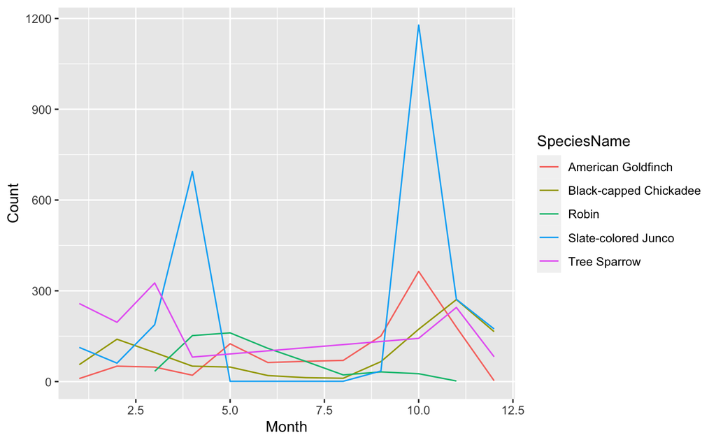

```r
# ggplot commands

ByMonth %>%
  ggplot(aes(x = Month, y = Count, color = SpeciesName)) +
  geom_line()
```

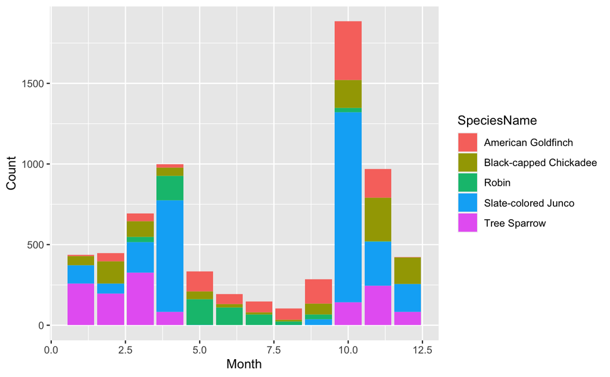

```r
ByMonth %>% ggplot(aes(x=Month,y=Count ,fill=SpeciesName)) +
  geom_bar(stat='identity',position='stack', width=.9)
```

According to the graph, we can answer the questions posed:

##### 2. Which species are migratory, that is, primarily present in one or two seasons?

*Tree-sparrow, Robin and Slate-colored Junco are primarily present in one or two seasons*

##### 3. What is the peak month for each major species? (bullet list)

```r
cat("Peak month for each major species:\n")
```

```
Peak month for each major species:
```

```r
cat("* American Goldfinch-October\n")
```

```
* American Goldfinch-October
```

```r
cat("* Black-capped Chickadee-November\n")
```

```
* Black-capped Chickadee-November
```

```r
cat("* Robin-May\n")
```

```
* Robin-May
```

```r
cat("* Slate-colored Junco-October\n")
```

```
* Slate-colored Junco-October
```

```r
cat("* Tree Sparro-March\n")
```

```
* Tree Sparro-March
```

##### 4. Which major species are seen in good numbers for at least 6 months of the year?

```r
# Find major species seen in good numbers for at least 6 months
six_month_species <- ByMonth %>%
  group_by(SpeciesName) %>%
  filter(n_distinct(Month) >= 6) %>%
  distinct(SpeciesName)

# Print the major species seen in good numbers for at least 6 months
cat("Major species seen in good numbers for at least 6 months:\n")
```

```
Major species seen in good numbers for at least 6 months:
```

```r
cat(paste("* ", six_month_species$SpeciesName, "\n", sep = ""))
```

```
* American Goldfinch
 * Black-capped Chickadee
 * Slate-colored Junco
 * Tree Sparrow
 * Robin
```